# Homework 11 R markdown

(your name here)

2018-07-18

#### **Intellectual Property:**

These problems are the intellectual property of the instructors and may not be reproduced outside of this course.

#### **Due Date:**

Tuesday, November 28, 2017 at 11:59 PM

## Problem 1: Clustering Methods

In this problem, you will explore clustering methods.

**Data Set**: Load the *wine.csv* data set (from the **rattle** package).

Description from the documentation for the R package **rattle**: “The wine dataset contains the results of a chemical analysis of wines grown in a specific area of Italy. Three types of wine are represented in the 178 samples, with the results of 13 chemical analyses recorded for each sample.” That is, we have n = 178 wine samples, each of which has p = 13 measured characteristics.

```
## [1] "Means for columns"
```

```
##         Alcohol           Malic             Ash      Alcalinity
##           13.00            2.34            2.37           19.49
##       Magnesium         Phenols      Flavanoids   Nonflavanoids
##           99.74            2.30            2.03            0.36
## Proanthocyanins           Color             Hue        Dilution
##            1.59            5.06            0.96            2.61
##         Proline
##          746.89
```

```
## [1] "Variances for columns"
```

```
##         Alcohol           Malic             Ash      Alcalinity
##            0.66            1.25            0.08           11.15
##       Magnesium         Phenols      Flavanoids   Nonflavanoids
##          203.99            0.39            1.00            0.02
## Proanthocyanins           Color             Hue        Dilution
##            0.33            5.37            0.05            0.50
##         Proline
##        99166.72
```

**Important Note**: It is carefully noted in each problem to standardize the data. Attention to those instructions will help you obtain the correct answers.

After loading in the data from the *wine.csv* file, store the 13 numeric variables in a data frame **x**.

### Question 1 **(1 point)**:

Compute the means and standard deviations for all the variables. Compare the means and standard deviations between the thirteen variables, using these values to explain why it is a good idea to standardize the variables before clustering.

**Text Answer**: The means of the colums are sustantially different - nearly 0 for Non-flavinoids to nearly 750 for Proline - so centering is definitely in order. The variances range from nearly 0 for Non-flavinoids to nearly 100,000 for Proline, so scaling is in order as well. With likely different units of measure, both actions are appropriate.

**Information**: Standardize the numeric variables in **x** and store the results in **x.scale**.

### Question 2 **(2 points)**:

Using Euclidean distance, fit the hierarchical model using complete linkage. Produce a dendrogram of all the clusters and upload to the Homework 11: Dendrogram discussion topic.

**Graph Answer** : (post to discussion board on D2L)

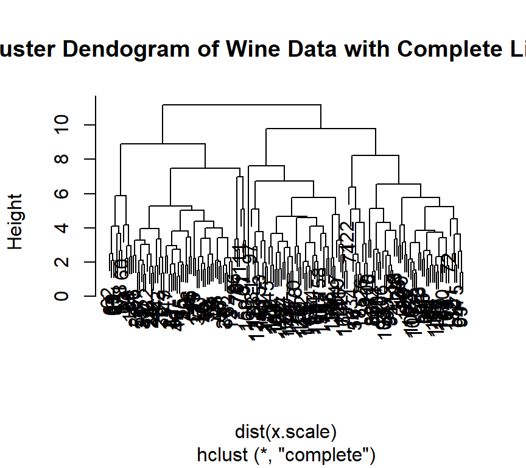

### Question 3 **(2 points)**:

List an appropriate “height” (corresponding to the value of the distance measure) on the dendrogram for complete linkage that would produce three clusters.

**Numeric Answer** **(AUTOGRADED on D2L)**: 9.75

```r
cutree(hc.complete, h=9.75)
```

```
##   [1] 1 1 1 1 2 1 1 1 1 1 1 1 1 1 1 2 2 2 1 1 1 1 1 1 1 2 1 1 2 1 1 1 1 2 1
##  [36] 1 1 1 1 1 1 1 1 1 1 1 1 1 1 1 1 1 1 2 1 1 1 1 1 1 1 1 1 2 1 1 1 2 1 1
##  [71] 1 2 2 2 2 1 1 1 1 2 2 2 2 3 2 2 1 2 2 2 2 2 2 2 2 1 3 2 2 2 1 2 2 2 2
## [106] 2 2 2 2 2 1 2 2 2 2 2 2 2 3 2 2 2 2 2 2 2 2 2 2 2 3 3 3 3 3 3 3 3 3 3
## [141] 3 3 3 3 3 3 3 3 3 3 3 3 3 3 3 3 3 3 3 3 3 3 3 3 3 3 3 3 3 3 3 3 3 3 3
## [176] 3 3 3
```

### Question 4 **(1 point)**:

Using Euclidean distance, fit the hierarchical model using each of single linkage and average linkage, as well as complete linkage. Which of the three linkage methods appears to produce the most similarly-sized clusters?

**Multiple choice Answer** **(AUTOGRADED on D2L)**: one of (COMPLETE) Complete linkage,  
Simple linkage,  
Average linkage

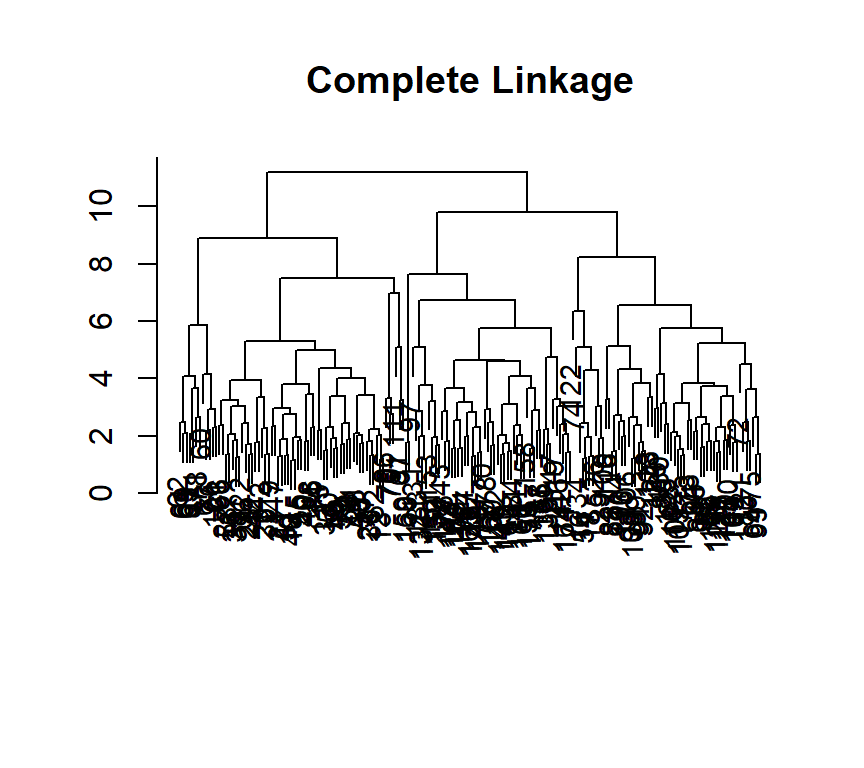

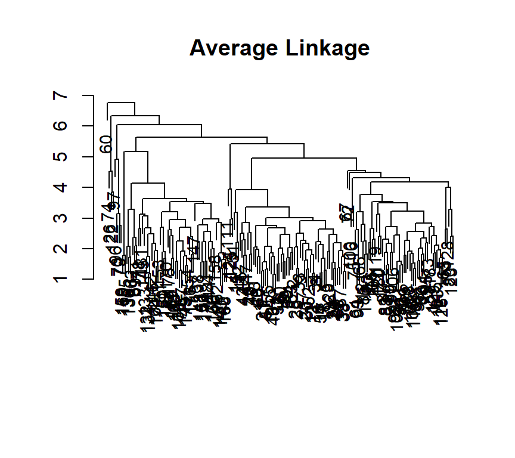

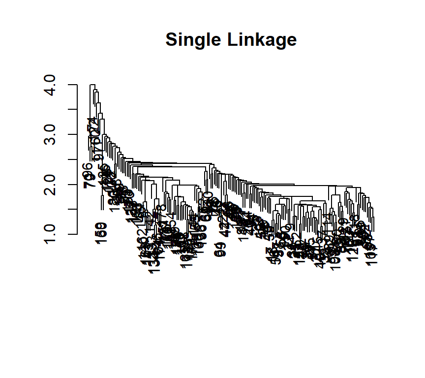

### Question 5 **(1 point)**:

Suppose we had further information that there are three types of wine, approximately equally represented, included in this data set. Which visually appears to be the most reasonable linkage method to designate those three clusters?

### Question 6 **(2 points)**:

Explain what you see visually in the dendrograms for the three linkage methods that supports your answer in the previous question.

**Text Answer**: For the complete linkage method at a height of around 9.75, a line would split the readings into three roughly equal clusters. Digging deeper, the counts for cutree(hc.complete, h=9.75) are 69, 58, and 51 respectively. For the other two linkage types, a split where three clusters exist results in a highly imbalanced count. They would not be representative of a roughly three-way split of wine varieties.

### Question 7 **(2 points)**:

Using the linkage method you selected to best designate three types of wine, for the split of the data in three clusters, make a plot of Alcohol versus Dilution marked by the clusters (using three different colors and/or symbols).

Upload your plot to Homework 11: Alcohol versus Dilution.

**Graph Answer** : (post to discussion board on D2L)

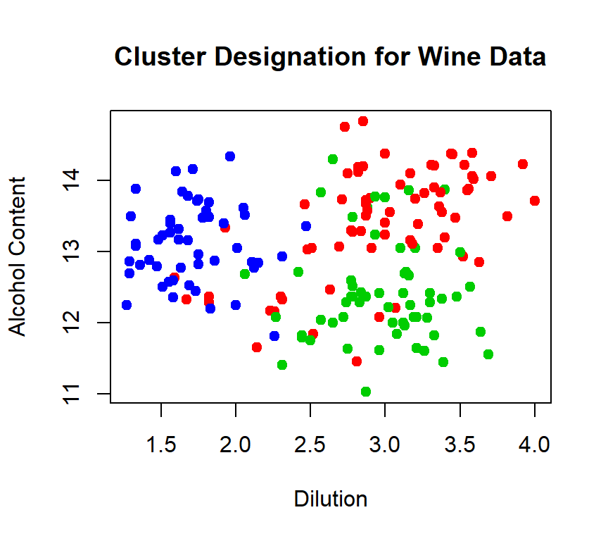

**Information**: Now we consider using nonhierarchical (K-means) clustering to split the data into clusters.

### Question 8 **(2 points)**:

For K-means clustering, use multiple initial random splits to produce K = 5, 4, 3, and 2 clusters. Use tables or plots to investigate the clustering memberships across various initial splits, for each value of K. Which number(s) of clusters seem to produce very consistent cluster memberships (matching more than 95% of memberships between different initial splits) across different initial splits? Select all K that apply.

**Multiple SELECT Answer** **(AUTOGRADED on D2L)**:

(2,3,4)

5,  
4,  
3,  
2

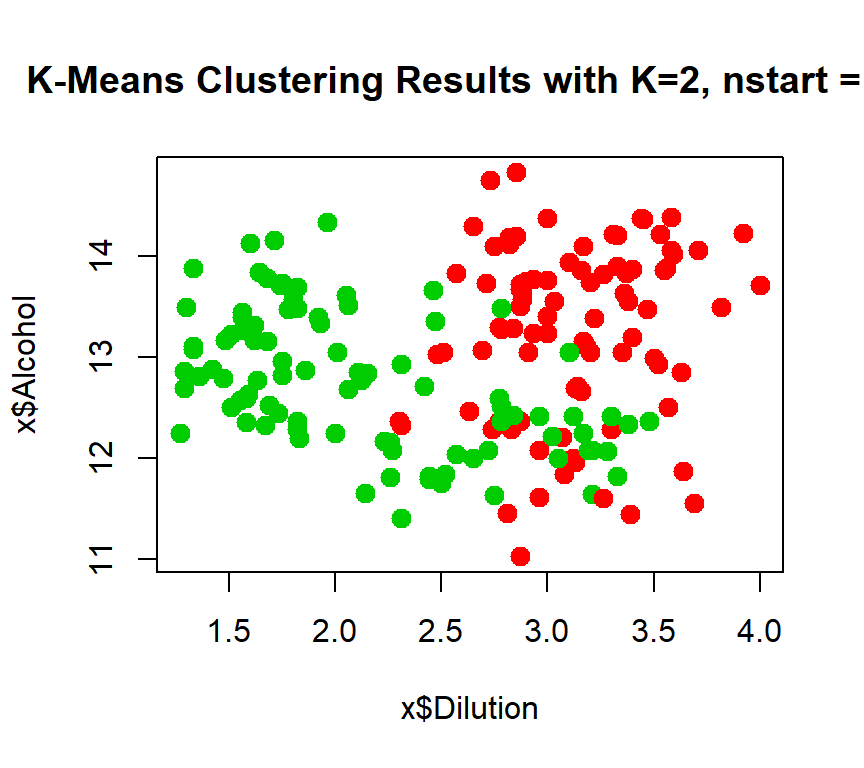

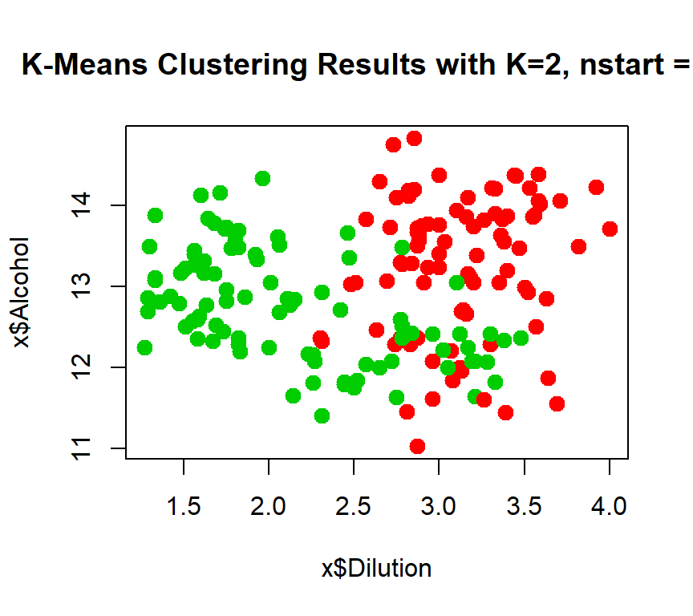

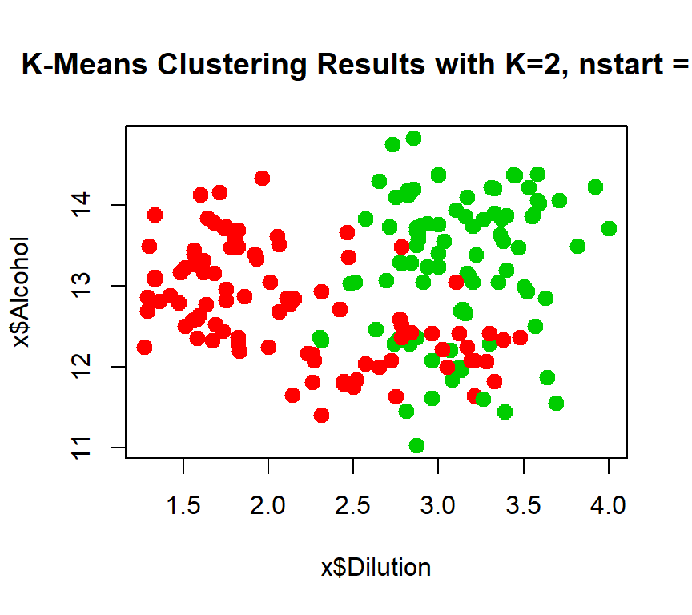

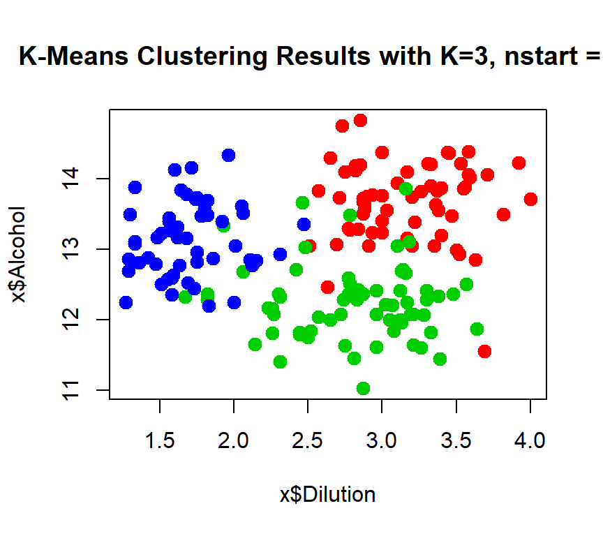

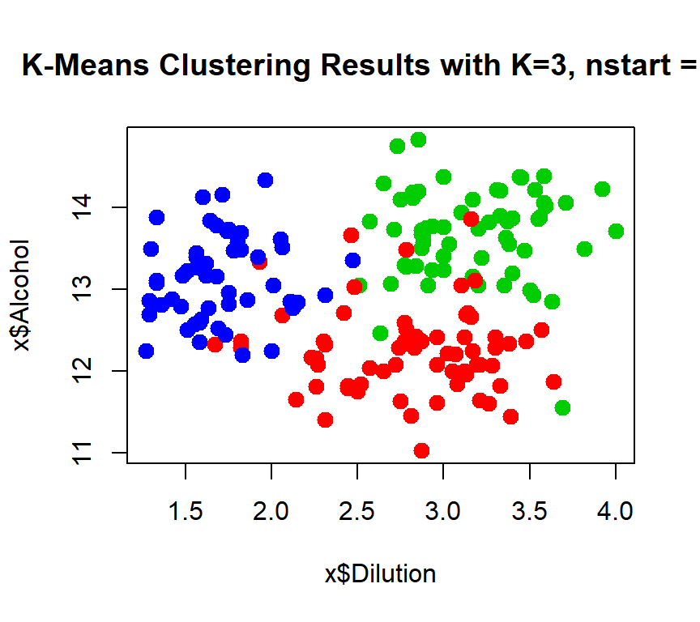

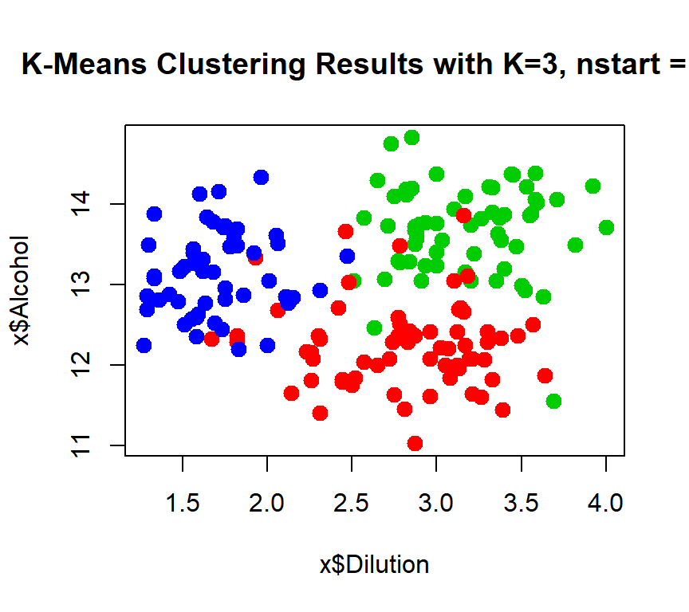

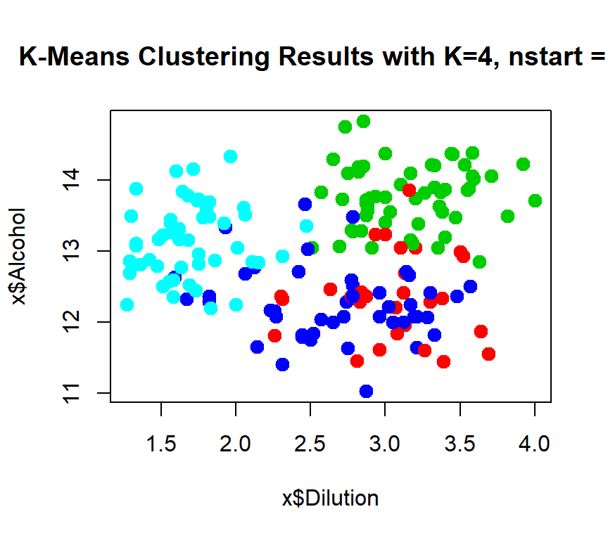

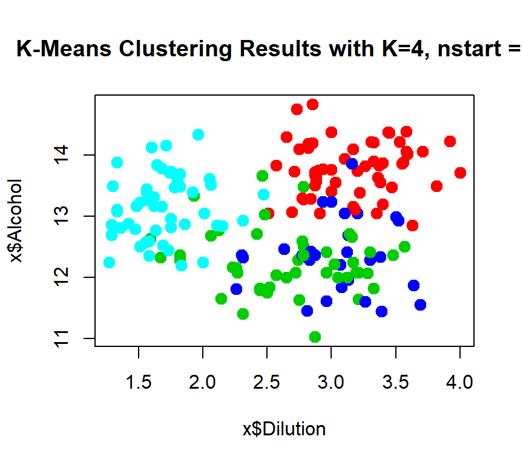

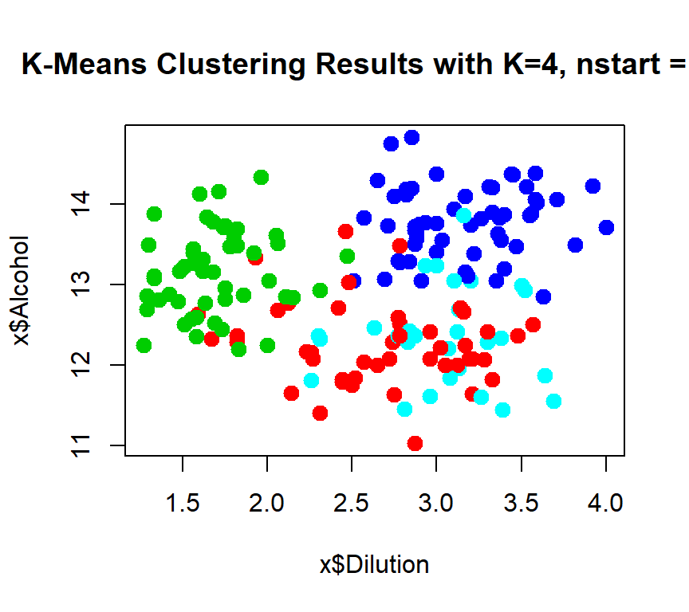

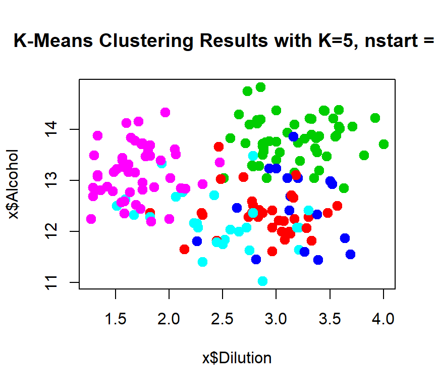

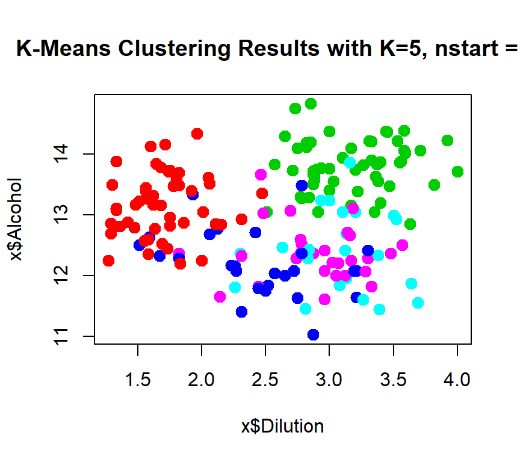

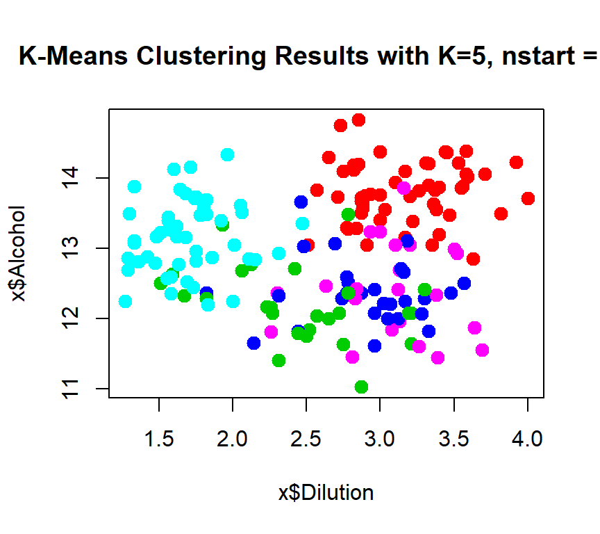

```
##   [,1] [,2] [,3]
## 1   33   48   54
## 2   54   54   26
## 3   17   26   28
## 4   26   22   48
## 5   48   28   22
```

```
##   [,1] [,2] [,3]
## 1   28   56   45
## 2   56   45   49
## 3   45   28   56
## 4   49   49   28
```

```
##   [,1] [,2] [,3]
## 1   62   65   65
## 2   65   62   62
## 3   51   51   51
```

```
##   [,1] [,2] [,3]
## 1   87   87   91
## 2   91   91   87
```

Starting with set.seed(12) to set the initial split, use nonhierarchical (K-means) clustering to determine cluster membership for three clusters (corresponding to the three types of wine). How many wine samples are in each cluster?

### Question 9 **(1 point)**:

Wine samples in Cluster 1:

**Numeric Answer** **(AUTOGRADED on D2L)**:

```
## [1] 62
```

### Question 10 **(1 point)**:

Wine samples in Cluster 2:

**Numeric Answer** **(AUTOGRADED on D2L)**:

```
## [1] 65
```

### Question 11 **(1 point)**:

Wine samples in Cluster 3:

**Numeric Answer** **(AUTOGRADED on D2L)**:

```
## [1] 51
```

### Question 12 **(2 points)**:

For splitting into three clusters, compare the cluster membership of hierarchical clustering (using the linkage method you selected when creating three clusters to designate three types of wine) to the cluster membership of K-means clustering (using the cluster membership from the previous question). What proportion of the cluster memberships match between the hierarchical and nonhierarchical clustering methods?

Proportion that match $\approx$

**Numeric Answer** **(AUTOGRADED on D2L)**:

```
## [1] 0.8426966
```

## Problem 2: PCA methods

We will continue to use the wine data set from Problem 1. We have *n* = 178 wine samples, each of which has *p* = 13 measured characteristics.

Load in the data from the *wine.csv* file. Store the 13 numeric variables in a data frame **x**.

We wish to use PCA to identify which variables are most meaningful for describing this dataset. Use the **prcomp** function, with *scale=T*, to find the principal components.

```
## Importance of components:
##                          PC1    PC2    PC3     PC4     PC5     PC6     PC7
## Standard deviation     2.169 1.5802 1.2025 0.95863 0.92370 0.80103 0.74231
## Proportion of Variance 0.362 0.1921 0.1112 0.07069 0.06563 0.04936 0.04239
## Cumulative Proportion  0.362 0.5541 0.6653 0.73599 0.80162 0.85098 0.89337
##                            PC8     PC9   PC10    PC11    PC12    PC13
## Standard deviation     0.59034 0.53748 0.5009 0.47517 0.41082 0.32152
## Proportion of Variance 0.02681 0.02222 0.0193 0.01737 0.01298 0.00795
## Cumulative Proportion  0.92018 0.94240 0.9617 0.97907 0.99205 1.00000
```

### Question 13 **(2 points)**:

Look at the loadings for the first principal component. What is the loading for the variable **Alcohol**?

**Numeric Answer** **(AUTOGRADED on D2L)**: -0.144329395

```
## Standard deviations (1, .., p=13):
##  [1] 2.1692972 1.5801816 1.2025273 0.9586313 0.9237035 0.8010350 0.7423128
##  [8] 0.5903367 0.5374755 0.5009017 0.4751722 0.4108165 0.3215244
##
## Rotation (n x k) = (13 x 13):
##                          PC1          PC2         PC3         PC4
## Alcohol         -0.144329395  0.483651548 -0.20738262  0.01785630
## Malic            0.245187580  0.224930935  0.08901289 -0.53689028
## Ash              0.002051061  0.316068814  0.62622390  0.21417556
## Alcalinity       0.239320405 -0.010590502  0.61208035 -0.06085941
## Magnesium       -0.141992042  0.299634003  0.13075693  0.35179658
## Phenols         -0.394660845  0.065039512  0.14617896 -0.19806835
## Flavanoids      -0.422934297 -0.003359812  0.15068190 -0.15229479
## Nonflavanoids    0.298533103  0.028779488  0.17036816  0.20330102
## Proanthocyanins -0.313429488  0.039301722  0.14945431 -0.39905653
## Color            0.088616705  0.529995672 -0.13730621 -0.06592568
## Hue             -0.296714564 -0.279235148  0.08522192  0.42777141
## Dilution        -0.376167411 -0.164496193  0.16600459 -0.18412074
## Proline         -0.286752227  0.364902832 -0.12674592  0.23207086
##                         PC5         PC6         PC7         PC8
## Alcohol         -0.26566365  0.21353865 -0.05639636  0.39613926
## Malic            0.03521363  0.53681385  0.42052391  0.06582674
## Ash             -0.14302547  0.15447466 -0.14917061 -0.17026002
## Alcalinity       0.06610294 -0.10082451 -0.28696914  0.42797018
## Magnesium        0.72704851  0.03814394  0.32288330 -0.15636143
## Phenols         -0.14931841 -0.08412230 -0.02792498 -0.40593409
## Flavanoids      -0.10902584 -0.01892002 -0.06068521 -0.18724536
## Nonflavanoids   -0.50070298 -0.25859401  0.59544729 -0.23328465
## Proanthocyanins  0.13685982 -0.53379539  0.37213935  0.36822675
## Color           -0.07643678 -0.41864414 -0.22771214 -0.03379692
## Hue             -0.17361452  0.10598274  0.23207564  0.43662362
## Dilution        -0.10116099  0.26585107 -0.04476370 -0.07810789
## Proline         -0.15786880  0.11972557  0.07680450  0.12002267
##                         PC9        PC10        PC11        PC12
## Alcohol         -0.50861912  0.21160473  0.22591696 -0.26628645
## Malic            0.07528304 -0.30907994 -0.07648554  0.12169604
## Ash              0.30769445 -0.02712539  0.49869142 -0.04962237
## Alcalinity      -0.20044931  0.05279942 -0.47931378 -0.05574287
## Magnesium       -0.27140257  0.06787022 -0.07128891  0.06222011
## Phenols         -0.28603452 -0.32013135 -0.30434119 -0.30388245
## Flavanoids      -0.04957849 -0.16315051  0.02569409 -0.04289883
## Nonflavanoids   -0.19550132  0.21553507 -0.11689586  0.04235219
## Proanthocyanins  0.20914487  0.13418390  0.23736257 -0.09555303
## Color           -0.05621752 -0.29077518 -0.03183880  0.60422163
## Hue             -0.08582839 -0.52239889  0.04821201  0.25921400
## Dilution        -0.13722690  0.52370587 -0.04642330  0.60095872
## Proline          0.57578611  0.16211600 -0.53926983 -0.07940162
##                        PC13
## Alcohol          0.01496997
## Malic            0.02596375
## Ash             -0.14121803
## Alcalinity       0.09168285
## Magnesium        0.05677422
## Phenols         -0.46390791
## Flavanoids       0.83225706
## Nonflavanoids    0.11403985
## Proanthocyanins -0.11691707
## Color           -0.01199280
## Hue             -0.08988884
## Dilution        -0.15671813
## Proline          0.01444734
```

### Question 14 **(1 point)**:

Which variable appears to contribute the **least** to the first principal component?

**Multiple choice Answer** **(AUTOGRADED on D2L)**: one of (ASH)

Alcohol

Malic

Ash

Alcalinity

Magnesium

Phenols

Flavanoids

Nonflavanoids

Proanthocyanins

Color

Hue

Dilution

Proline

### Question 15 **(1 point)**:

What is the PVE for the first principal component?

**Numeric Answer** **(AUTOGRADED on D2L)**: 0.3619885

```
##  [1] 0.361988481 0.192074903 0.111236305 0.070690302 0.065632937
##  [6] 0.049358233 0.042386793 0.026807489 0.022221534 0.019300191
## [11] 0.017368357 0.012982326 0.007952149
```

### Question 16 **(2 points)**:

How many principal components would need to be used to explain about 80% of the variability in the data?

**Numeric Answer** **(AUTOGRADED on D2L)**: 5

```
##  [1] 0.3619885 0.5540634 0.6652997 0.7359900 0.8016229 0.8509812 0.8933680
##  [8] 0.9201754 0.9423970 0.9616972 0.9790655 0.9920479 1.0000000
```

On a biplot of the data, wine sample #159 appears to be an outlier in the space of principal components 1 and 2. What are the principal component 1 and 2 score values (that is, the coordinates in the space of principal components 1 and 2) for wine sample #159?

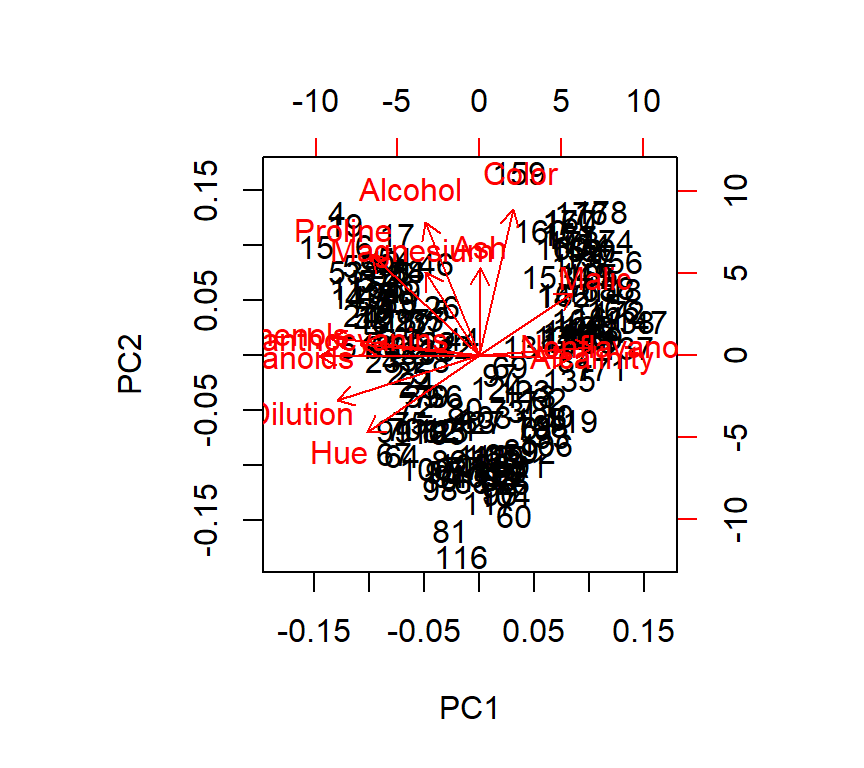

```
##      PC1      PC2
## 1.045233 3.505202
```

### Question 17 **(1 point)**:

Principal component 1 score value $\approx$

**Numeric Answer** **(AUTOGRADED on D2L)**:

### Question 18 **(1 point)**:

Principal component 2 score value $\approx$

**Numeric Answer** **(AUTOGRADED on D2L)**:

## Problem 3: Gene Expression Application

Find the gene expression data set GeneExpression.csv in the online course. There are 40 tissue samples, each with measurements on 1000 genes. Note that this dataset is “transposed” from typical format; that is, the variables (gene expression measurements) are listed in the rows, and the data points (tissue samples) that we want to group or identify are listed in the columns. That is, we have n = 40 tissue samples, each of which has p = 1000 observed gene expression measurements.

The goal is to distinguish between healthy and diseased tissue samples.

Data preparation:

1. Load in the data using *read.csv(“GeneExpression.csv”,header=F)*. Note the header=F argument is used to identify that there are no column names.
2. Be sure to transpose the data frame before using it for analysis.
3. Standardize the 1000 variables to each have mean 0 and standard deviation 1.

You should wind up with a data frame of size 40 rows (tissue samples) by 1000 columns (gene expression measurements).

Using the properly prepared data, complete the following tasks.

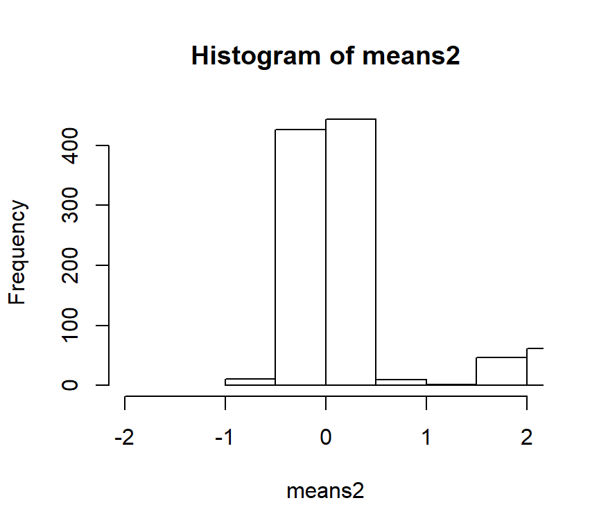

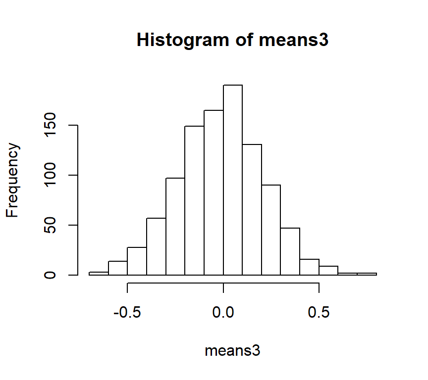

### Question 19 **(2 points)**:

[*Image is available only on D2L quiz question.*]

The means of all 1000 standardized variables are computed for only the last twenty tissue samples (samples 21-40) – store these as means2. A histogram of these 1000 means is displayed above.

Describe the distribution visualized in the histogram. What do you think this pattern may suggest, in terms of comparing the first 20 tissue samples to the last 20 tissue samples?

**Text Answer**: Histograms comparing the means of the two groups of tissue samples suggests that the two samples are from different groups that exhibit measurements that are different enough to separate through our unsupervised methods.

### Question 20 **(2 points)**:

Based on the goal of the study, explain why it makes sense to split the data into only two clusters.

### Question 21 **(1 point)**:

Use hierarchical clustering with Euclidean distance and complete linkage to split the data into two clusters. How many tissue samples from among samples 21-40 are in the second cluster?

**Numeric Answer** **(AUTOGRADED on D2L)**:

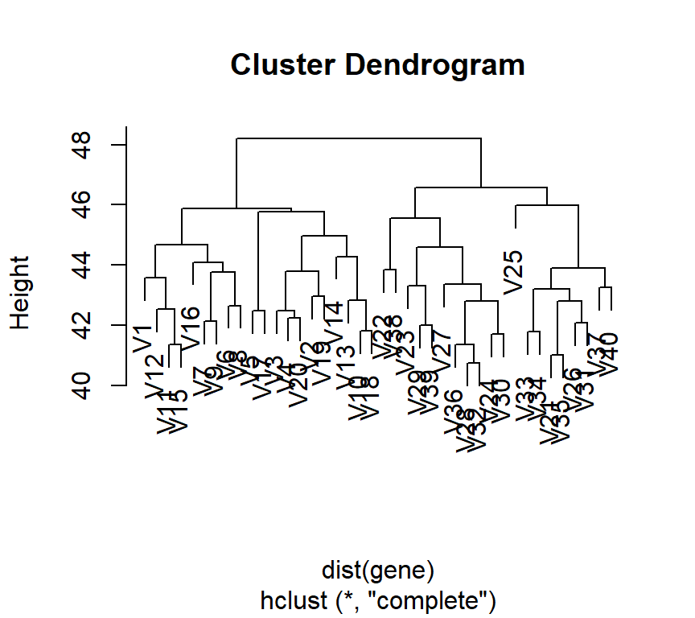

```
##  V1  V2  V3  V4  V5  V6  V7  V8  V9 V10 V11 V12 V13 V14 V15 V16 V17 V18
##   1   1   1   1   1   1   1   1   1   1   1   1   1   1   1   1   1   1
## V19 V20 V21 V22 V23 V24 V25 V26 V27 V28 V29 V30 V31 V32 V33 V34 V35 V36
##   1   1   2   2   2   2   2   2   2   2   2   2   2   2   2   2   2   2
## V37 V38 V39 V40
##   2   2   2   2
```

```
## [1] "There are 20 in cluster 1 and 20 in cluster 2."
```

### Question 22 **(2 points)**:

Tissue samples 1-20 are healthy, and tissue samples 21-40 are diseased. What do the results of the clustering from the previous question tell us about the ability of the gene expression measurements to identify diseased tissue?

**Text Answer**: That’s an exact match. The clustering grouped them successfully.

### Question 23 **(1 point)**:

Use prcomp to compute the principal components. How many principle components are able to be computed?

Number of principal components $\approx$

**Numeric Answer** **(AUTOGRADED on D2L)**: 40

```
##           PC1           PC2           PC3           PC4           PC5
## -8.367457e+00 -4.386020e+00  2.835405e+00 -1.893885e+00  1.197021e+01
##           PC6           PC7           PC8           PC9          PC10
## -1.580379e+00  5.280058e+00 -2.358669e+00 -3.160096e+00 -2.448195e+00
##          PC11          PC12          PC13          PC14          PC15
## -1.820806e+00  3.596275e+00  1.604952e+00 -1.281410e+00 -3.942536e+00
##          PC16          PC17          PC18          PC19          PC20
## -1.732345e+01  8.726415e+00  6.918545e+00 -2.883793e+00 -4.721042e+00
##          PC21          PC22          PC23          PC24          PC25
## -5.786154e+00 -5.150296e-01  4.377941e+00  1.173316e+00  5.401535e+00
##          PC26          PC27          PC28          PC29          PC30
## -4.769019e+00 -2.204439e-01 -1.003863e+00  8.325421e+00 -6.768296e-01
##          PC31          PC32          PC33          PC34          PC35
## -3.154780e+00 -7.795108e-02  2.868025e-01  9.956220e-01  2.692877e+00
##          PC36          PC37          PC38          PC39          PC40
## -1.584824e+00  3.077684e+00 -1.756292e-01  3.405772e+00  6.195050e-15
```

### Question 24 **(2 points)**:

What is the cumulative PVE explained by the first two principal components?

**Numeric Answer** **(AUTOGRADED on D2L)**:

```
##  [1] 0.08108273 0.11557514 0.14856256 0.18012518 0.21096586 0.24122766
##  [7] 0.27039513 0.29940142 0.32830488 0.35683603 0.38512548 0.41268970
## [13] 0.43959850 0.46629359 0.49234273 0.51781165 0.54314153 0.56803427
## [19] 0.59230319 0.61641089 0.64030372 0.66384163 0.68687912 0.70974687
## [25] 0.73185294 0.75357830 0.77516319 0.79624909 0.81679225 0.83680721
## [31] 0.85651100 0.87601827 0.89532586 0.91432788 0.93226341 0.95005869
## [37] 0.96711031 0.98370605 1.00000000 1.00000000
```

```
## [1] "The first two principal components explain 0.1155751 of the PVE."
```

### Question 25 **(1 point)**:

Produce a biplot of the first two principal components and upload it to the Homework 11: Biplot of Two Principal Components discussion topic.

**Graph Answer** : (post to discussion board on D2L)

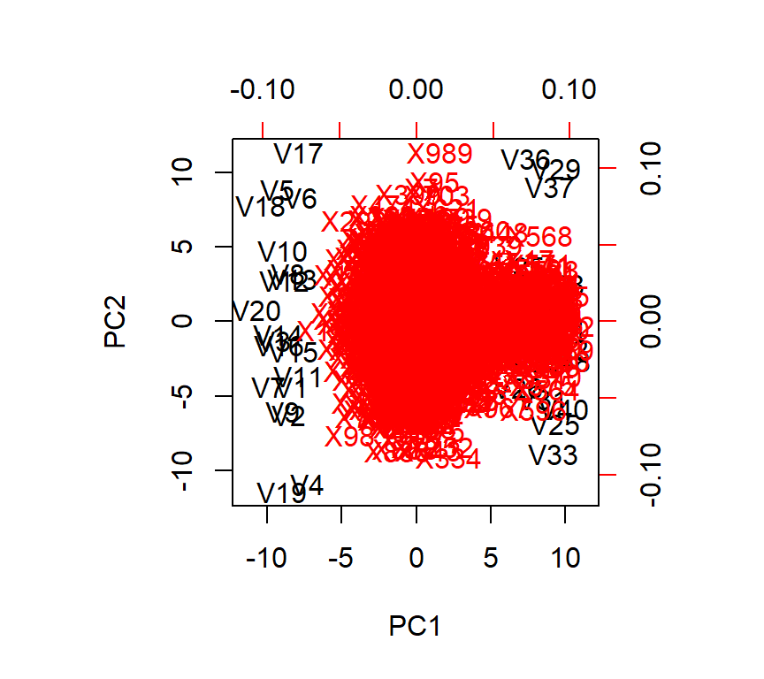

### Question 26 **(2 points)**:

Explain what this tells us about the variables that are most meaningful in the first principal component.

[*Image is available only on D2L quiz question.*]